# Tuango - RFM Analysis for Mobile App Push Messaging on the post roll-out data

- Name: Shihan Wang
- GitLab id: rsm-shw005

## Setup

Please complete this Rmarkdown document by answering question 14 in `tuango.pdf` on Canvas (week4/). The code block below loads the data you need for this second Rmarkdown file. Create an HTML file with all your results and answers and push both the Rmarkdown and HTML file to GitLab when you are done. All results MUST be reproducible (i.e., the TA and I must be able to recreate the Notebook/HTML from the Rmarkdown file without changes or errors).

```r
## loading the data - this dataset must NOT be changed
tuango_post <- readr::read_rds("data/tuango_post.rds")
```

## Question answers

14. You also have access to a dataset with the results from the SMS roll-out (tuango_post.rds or tuango_post.pkl). Tuango actually contacted all 250,902 customers. The data has a “training” variable (training = 1 for the data used in the test, training = 0 for the remaining customers). You can use this variable to help evaluate the actual performance for each of the different RFM approaches. Re-create the plot in question 13 based on this new dataset. Use the “tuango_post.Rmd” or “tuango_post.ipynb” file as a starting point to answer the question and conduct all analyses. You should be able to reuse most of your code and text from “tuango.Rmd” or “tuango.ipynb”. However, you may need to make a few changes to your “perf_calc” function. Make sure to check that your “rfm_iq” variable is the same as “rfm_iq_pre” in the “tuango_post.rds” (or “tuango_post.pkl”) dataset. Hint: It is important to note that, you should not use any information about buyers that were not in the test sample (i.e., training == 0) to calculate the break-even response rate etc. for targeting.

```r
#rfm_iq
tuango_post <- tuango_post %>%
  mutate(rec_iq = xtile(recency, 5),
         freq_iq = 6L - xtile(frequency, 5),
         mon_iq = xtile(monetary, 5, rev = TRUE)) %>%
  mutate(rfm_iq = paste0(rec_iq, freq_iq, mon_iq))


#rfm_sq
tuango_post <- tuango_post %>%
  group_by(rec_iq) %>%
  mutate(freq_sq = xtile(frequency, 5, rev = TRUE)) %>%
  ungroup()

tuango_post <- tuango_post %>%
  group_by(rec_iq, freq_sq) %>%
  mutate(mon_sq = xtile(monetary, 5, rev = TRUE)) %>%
  ungroup() %>%
  mutate(rfm_sq = paste0(rec_iq, freq_sq, mon_sq))

tuango_post_nft <- tuango_post %>%
  filter(training == 0)

tuango_post_t <- tuango_post %>%
  filter(training == 1)
```

```r
# average spending
average_t <- tuango_post_t %>%
  filter(buyer == 'yes') %>%
  summarise(avg = mean(ordersize))
avg <- average_t$avg
avg
```

```
[1] 202.1288
```

```r
mc <- 2.5
cos <- 0.5
#define function
perf_calc_t <- function(sms, intro) {
  dat = filter(tuango_post_nft, tuango_post_nft[,sms] == TRUE)
  n = nrow(dat)
  profit = cos*sum(dat$ordersize) - mc*n
  rome = profit/(mc*n)
  print(paste(intro,  'cost is ', mc*n, ', profit is', profit, ', and ROME is', rome ))
  return(tibble::tibble('profit' = profit, 'rome' = rome))
}
```

```r
breakeven <- mc/(cos*avg)
breakeven
```

```
[1] 0.02473671
```

```r
#Q9 iq

tuango_post_nft <- tuango_post_nft %>%
  group_by(rfm_iq) %>%
  mutate(smsto_iq_t9 = mean(buyer == "yes") > breakeven) %>%
  ungroup()
res_iq_t9 <- perf_calc_t(sms = "smsto_iq_t9", intro = "Based on independent RFM")
```

```
[1] "Based on independent RFM cost is  265300 , profit is 335967 , and ROME is 1.26636637768564"
```

```r
#Q9 sq

tuango_post_nft <- tuango_post_nft %>%
  group_by(rfm_sq) %>%
  mutate(smsto_sq_t9 = mean(buyer == "yes") > breakeven) %>%
  ungroup()
res_sq_t9 <- perf_calc_t(sms = "smsto_sq_t9", intro = "Based on sequential RFM")
```

```
[1] "Based on sequential RFM cost is  255420 , profit is 342709 , and ROME is 1.34174692663065"
```

```r
#Q11
tuango_post_t <- tuango_post_t %>%
  group_by(rfm_sq) %>%
  mutate(rev_sq = ifelse(sum(ordersize) == 0, 0, sum(ordersize)/sum(buyer == "yes"))) %>%
  ungroup()

tuango_post_t1 <- tuango_post_t %>%
  mutate(breakeven_sq = ifelse(rev_sq == 0, 0, mc/(cos * rev_sq))) %>%
  select(rfm_sq, breakeven_sq) %>%
  distinct()

tuango_post_nft <- tuango_post_nft %>%
  group_by(rfm_sq) %>%
  left_join(tuango_post_t1, by = 'rfm_sq') %>%
  mutate(smsto_sq11 = mean(buyer == 'yes') > breakeven_sq) %>%
  ungroup()


res_sq_11 <- perf_calc_t(sms = "smsto_sq11", intro = "Based on sequential RFM")
```

```
[1] "Based on sequential RFM cost is  243720 , profit is 344175 , and ROME is 1.41217380600689"
```

```r
#12iq
tuango_post_nft <- tuango_post_nft %>%
  group_by(rfm_iq) %>%
  mutate(smsto_iqlbt = (mean(buyer == "yes") - 1.64 * seprop(buyer == "yes")) > breakeven) %>%
  ungroup
res_iqlb_12 <- perf_calc_t(sms = "smsto_iqlbt", intro = "Based on independent RFM")
```

```
[1] "Based on independent RFM cost is  219892.5 , profit is 331553.5 , and ROME is 1.50779812863104"
```

```r
#12sq

tuango_post_nft <- tuango_post_nft %>%
  group_by(rfm_sq) %>%
  mutate(smsto_sqlbt = (mean(buyer == "yes") - 1.64 * seprop(buyer == "yes")) > breakeven) %>%
  ungroup
res_sqlb_12 <- perf_calc_t(sms = "smsto_sqlbt", intro = "Based on sequential RFM")
```

```
[1] "Based on sequential RFM cost is  221352.5 , profit is 340033 , and ROME is 1.536160648739"
```

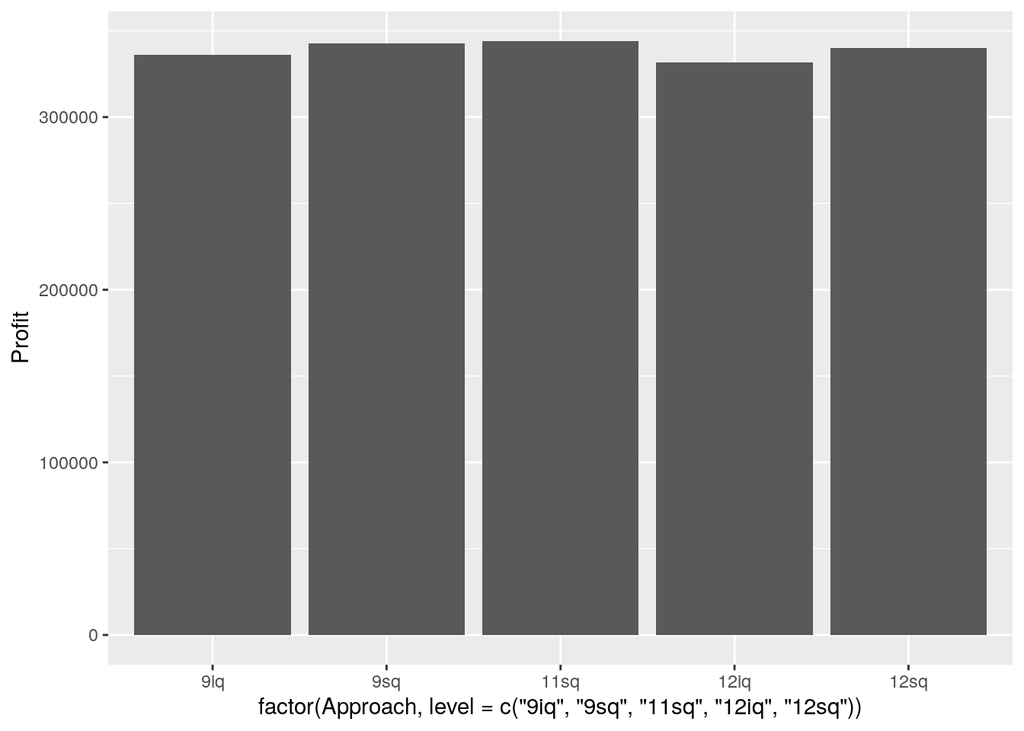

```r
#bar plot

result <- tibble::tibble( Profit = c('9iq' = res_iq_t9$profit, '9sq' = res_sq_t9$profit, '11sq' = res_sq_11$profit, '12iq' = res_iqlb_12$profit, '12sq' = res_sqlb_12$profit),
                          ROME =  c('9iq' = res_iq_t9$rome, '9sq' = res_sq_t9$rome, '11sq' = res_sq_11$rome, '12iq' = res_iqlb_12$rome, '12sq' = res_sqlb_12$rome),
                          Approach = c('9iq', '9sq', '11sq', '12iq', '12sq'))

ggplot(result, aes(factor(Approach, level = c('9iq', '9sq', '11sq', '12iq', '12sq')), Profit)) + geom_col()
```

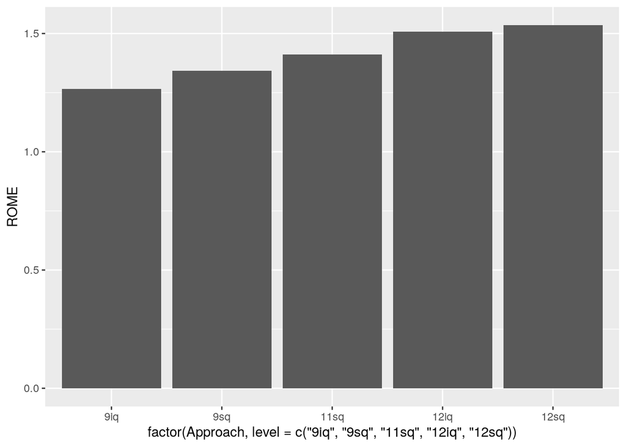

```r
ggplot(result, aes(factor(Approach, level = c('9iq', '9sq', '11sq', '12iq', '12sq')), ROME)) + geom_col()
```